# project on reproducible research

sconfumberto

2023-05-31

## Exploratory analysis of activity monitoring data

In this R Markdown document is described the step-by-step process to accomplish the 4 tasks required by the project.

### Loading packages and the data

In the code chunk below, the csv file is extraced and read into R

```r
#loads the required packages
library(ggplot2)
library(knitr)
library(readr)
library(dplyr)
#extracts the csv file from the zip
url <- "https://d396qusza40orc.cloudfront.net/repdata%2Fdata%2Factivity.zip"

working_dir <- getwd()

dest_zip_file <- file.path(working_dir, "data.zip")

dest_csv_file <- file.path(working_dir, "activity.csv")

download.file(url, dest_zip_file, method = "auto")

unzip(dest_zip_file, files = "activity.csv", exdir = working_dir)

if(file.exists(dest_csv_file)) {
  cat("CSV file extracted successfully")
} else {
  cat("Failed to extract the CSV file")
}
```

```
## CSV file extracted successfully
```

```r
#reads the csv file
data <- read_csv("activity.csv")
```

### Preliminary cleaning of the dataset

The first assignment (below) suggested that I could ignore the missing values (NAs), however I have interpreted this as a way of saying that I could ignore them, but also that I could not if I wanted to. As a consequence, I decided to deal with missing values right away. Therefore, task 3 below, will not deal anymore with the issue of imputing missing values.

Furthermore, in this task, I have also dealt right away with the days of the week, because I thought it was important to know from the beginning which days were weekday and which ones were weekends. Therefore, task 4 below, will not deal anymore with this issue of finding the day of the week.

```r
#counts NAs in each column
na_count_steps <- sum(is.na(data$steps))
print(na_count_steps)
```

```
## [1] 2304
```

```r
na_count_date <- sum(is.na(data$date))
print(na_count_date)
```

```
## [1] 0
```

```r
na_count_interval <- sum(is.na(data$interval))
print(na_count_interval)
```

```
## [1] 0
```

```r
#only the steps column has NAs

#adds a column with the days of the week
# Add a new column indicating weekday or weekend
data$day_name <- ifelse(weekdays(data$date) %in% c("Saturday", "Sunday"), "Weekend", "Weekday")

#calculates the median and mean of steps on both weekdays and weekends
median_weekdays <- data %>%
  filter (day_name == "Weekday") %>%
  summarize(med_days = median(steps, na.rm = TRUE))

median_weekends <- data %>%
  filter (day_name == "Weekend") %>%
  summarize(med_ends = median(steps, na.rm = TRUE))

mean_weekdays <- data %>%
  filter (day_name == "Weekday") %>%
  summarize(mean_days = mean(steps, na.rm = TRUE))

mean_weekends <- data %>%
  filter (day_name == "Weekend") %>%
  summarize(mean_ends = mean(steps, na.rm = TRUE))

#since the median of both weekdays and weekends is the same, i.e. 0, I substitute 0 for NAs in the whole steps column
data$steps[is.na(data$steps)] <- 0
```

### What is mean total number of steps taken per day?

See the code chunk below

```r
total_steps <- data %>%
  group_by(date) %>%
  summarize (total_per_day = sum(steps))

#prints the total steps
print (total_steps)
```

```
## # A tibble: 61 × 2
##    date       total_per_day
##    <date>             <dbl>
##  1 2012-10-01             0
##  2 2012-10-02           126
##  3 2012-10-03         11352
##  4 2012-10-04         12116
##  5 2012-10-05         13294
##  6 2012-10-06         15420
##  7 2012-10-07         11015
##  8 2012-10-08             0
##  9 2012-10-09         12811
## 10 2012-10-10          9900
## # ℹ 51 more rows
```

```r
mean_per_day <- mean(total_steps$total_per_day)

#prints the mean
print (mean_per_day)
```

```
## [1] 9354.23
```

```r
median_per_day <- median(total_steps$total_per_day)

#prints the median
print (median_per_day)
```

```
## [1] 10395
```

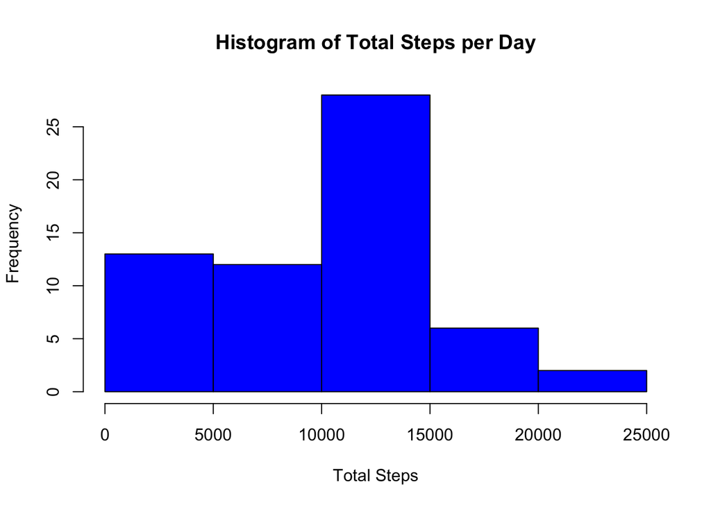

```r
#makes the plot
hist(total_steps$total_per_day,
     main = "Histogram of Total Steps per Day",
     xlab = "Total Steps",
     ylab = "Frequency",
     col = "blue")
```